# Computing

## Packages

Because R is an open-source program, it is easy to write extensions, and thousands of people have. These extensions come in the form of “packages” and these packages contain mostly functions that do stuff with data. For example, I’ve written an R package that does plotting. I’ve written another package that estimates statistical model. Hadley Wickam has written many R packages, some of which we’ll use. He’s written `haven`, which we can use to read proprietary data formats, such as Stata (`.dta`) files. He’s also written `readr`, which we can use to *quickly* read in better formats, such as comma-separated values (`.csv`), which I’ll encourage you to use throughout the course. He’s also written a package that is helpful for creating plots called `ggplot2`. We see that later.

In order to use a package, it must be installed once and then loaded in each session (i.e., after each restart). Some packages come pre-installed in R (e.g., `stats`, `MASS`). Some of these pre-installed packages are automatically loaded in each session (e.g., `stats`), while others must be loaded manually in each session (e.g., `MASS`) if you want to use them. Other packages that do not come pre-installed with R need to be installed manually (but just once) and loaded in each session.

### Installing Packages

If you click the “Packages” tab in RStudio (positioned in the upper-right panel by default), it will show you a list packages that are currently installed. I’ve attached a screenshot of my installed packages below, but your’s might look slightly different–I’ve probably installed a lot more than you.

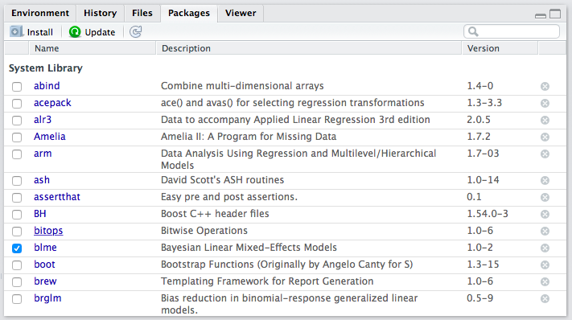

If you want to use a function from a package and it is **not installed**, you must first install it. Most R packages are available on CRAN, and can be installed with the `install.packages()` function.

```
install.packages("haven")
install.packages("readr")
install.packages("dplyr")
install.packages("ggplot2")
```

If you want to go ahead and install these packages, feel free–we’ll use them later. RStudio might ask you to choose a mirror. If so, just choose something close to you–it doesn’t really matter.

If you look at your list of installed packages again, you should see `haven`, `readr`, `dplyr`, `ggplot2` there.

You only need to install a package once. Once you’ve installed it, you have it on your hard drive.

### Loading Packages

In order to use function from a package, though, the package must be installed *and* loaded. In the packages list, the check box (beside the package name) indicates whether the package is loaded. In the screenshot above, you can see that I only had one package loaded at the time I took the screenshot–`blme`, a package useful for estimating Bayesian linear mixed-effects models.

Let’s see how to access functions that are in packages. First, let’s create some data to plot.

```r
x <- c(1, 3, 2, 5, 4)
y <- c(2, 1, 4, 3, 5)
```

Now let’s try to use the `qplot()` function in the `ggplot2` package to create a scatterplot of `x` and `y`. I’m assuming that you’ve already installed the `ggplot2` package.

Now, let’s try to use `qplot()`.

```r
qplot(x, y)
```

```
## Error in eval(expr, envir, enclos): could not find function "qplot"
```

You’ll notice that the `qplot()` function cannot be found. That’s because while `ggplot2` is *installed* (i.e., present in the library), it is not loaded (i.e., off the shelf). If you want to use a function from the `ggplot2` package, you need to load the package using the `library()` function. You need to load the package each time you start a new session (e.g., restart RStudio), so be sure to include this in your script. Notice that you do not need to use quotes around the name of the package when using the `library()` function.

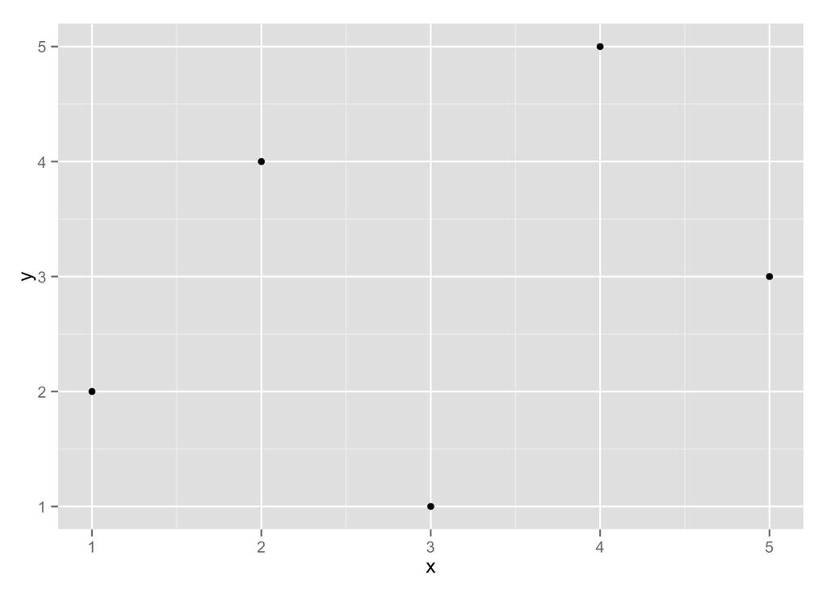

```r
library(ggplot2)
qplot(x, y)
```

When we use `library()`, it loads the entire set of functions in the package into our workspace, making them all accessible to us. There are litterally hundreds of functions in the `ggplot2` package. If we prefer to avoid loading all the functions, we can use the syntax `package::function()` to tell R where to find the function in the library without loading all the functions into the workspace.

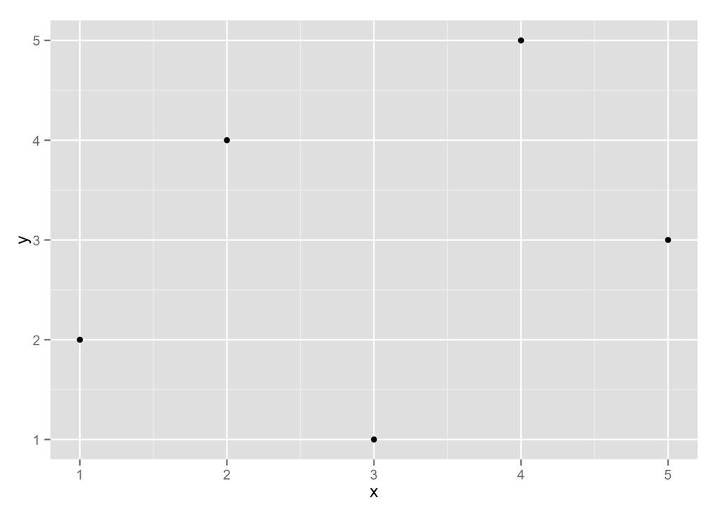

```r
ggplot2::qplot(x, y)
```

`ggplot2::qplot(x, y)` will work whether or not `ggplot2` is loaded.

I don’t have strong feelings about which approach is better. If you only need to use one function from package one time, then perhaps it makes more sense to use the `package::function()` approach. If you’ll be using many functions many times, then it makes sense to use `library()`. Use whichever makes most sense to you. However, I’ll tend to use `package::function()` a lot, because it makes it clear where the function is coming from.

## Loading Data Sets

Rather than manually entering data using `c()`, we’ll want to load data in stored in a data file. For this class, these will usually be comma-separated value or `.csv` files. These are my preferred format. To load these files, we’ll just use the `read.csv()` function. This requires you to set the working directory and point `read.csv()` to the file within that directory. Note that the `read.csv()` is a part of the `utils` package and is automatically loaded by default when R starts.

### Comma-Separated Value Format (`.csv`)

Data can be stored in a wide range of formats. One popular format, for example, is Stata’s proprietary `.dta` format. However, I’m going to use (and encourage you to use) the comma-separated values `.csv` format. The `.csv` format is excellent because it is open and simple. This means that anyone can use it without acess to proprietary software. It will also be useble by anyone into the foreseeable future. We can see why `.csv` files are easy to work with if we open it up the file `nominate.csv` with a text editor. You’ll see that you can read the file directly. You don’t really need software, you can do it with your eyes!

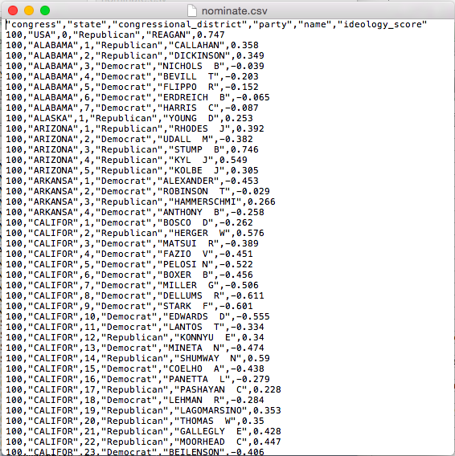

I tried the same thing for a similar `.dta` file. You can see that it looks like nonsense. You’ll definitely need Stata (or other speciallized software) to work with this file.

[figure not shown]

Also, `.csv` files are easy to support, so they work in almost all data analysis software. For example, we can open up `nominate.csv` in Excel. You can see that we have six variables in the columns and many cases in the rows (we don’t know how many because they overflow the screen). In this case, each row represents a particular Congressman or Congresswoman from a particular Congress (and Presidents are also included). The second row, for example, is for Rep. Callahan (R) from the 1st Congressional District of Alabama. During the 100th Congress, Rep. Calahan has a ideology score of 0.358, which means he’s conservative, but not as conservative as Pres. Reagan, who has a score of 0.747. We’ll work with these data a lot thoughout the semester, so we’ll have plenty of time for closer examination.

[figure not shown]

### Setting the Working Directory

Each project you work on should have it’s own directory (i.e., folder). For example, I have a folder for each class I teach and each paper I write. I have code and data for each class I teach and each paper I write. At the beginning of my R session, I simply set the working directory to the directory for the class or paper that I want to work on. To set the working directory in RStudio, click “Session,” “Set Working Directory,” “Choose Directory.” Then naviagte to and choose the directory of the project (e.g., class or paper) you want to work on.

But what should a project folder look like? It should be very well organized. I recommend you have two for this class, one for the class material (e.g., notes, data, code, etc.) and another for the paper you’ll write. I recommend something like the following structure for the class directory.

```
class-folder
  |--data
  |--notes
  |--R
  |--readings
```

You can name `class-folder` anything you like, but I recommend not using spaces. You can include other subdirectories as you like, but the important point is to have a `data` subdirectory in which you keep all the data that you load into R. The directory `R` holds all your R code for the class, named informatively (e.g., `intro-to-R.R`, `histograms.R`). You can keep any notes in the `notes` directory and any readings in the `readings` directory.

And I recommend something like the following for your paper.

```
project-folder
  |--data
  |--R
  |--doc
    |--figs
  |--lit
```

Again, name `project-folder` something short and descriptive, avoiding spaces. As before, the `data` directory holds the data for your project, the `R` directory holds all the R scripts. The `doc` directory holds the paper, perhaps in Microsoft Word or whatever you use to write papers. I recommend keeping the figures in a separate directory `figs` inside the `doc` directory. You might use a directory `lit` to keep up with any literature you reference as part of your project.

### Reading the Data

Once you’ve set up your project directory and saved the data to the `data` subdirectory, loading data is a easy, you just need to tell `read.csv()` where to look for the data. Suppose that we’ve saved a data set as `cool-data.csv` to `project-folder/data`.

If the data where in the working directory (`project-folder` in this example), then we could just use `read.csv("cool-data.csv")`. But the data is not in the working directory, it is in a subdirectory. We just need to include the subdirectory and the filename, so that `read.csv("data/cool-data.csv")`.

Because we’ll set the working directory to the folder dedicated to the project we’re working on, and we’ll always save data to the subdirectory `data`. This will be really easy.

To practice, go ahead and create a directory for this class. Then download the data set `nominate.csv` from URL and save it as `nominate.csv` in the `data` subdirectory. Open RStudio and set the working directory to your class folder. Now let’s read those data into R.

```r
# Before this will work:
# 1.) Save the file nominate.csv to your data subdirectory in your class folder.
# 2.) set the working directory to the class folder.

# load packages
library(dplyr)  # for glimpse() function
# read data
nominate <- read.csv("data/nominate.csv")

# check that data read properly
glimpse(nominate)  # quick look at the data
```

```
## Observations: 6173
## Variables:
## $ congress               (int) 100, 100, 100, 100, 100, 100, 100, 100,...
## $ state                  (fctr) USA, ALABAMA, ALABAMA, ALABAMA, ALABAM...
## $ congressional_district (int) 0, 1, 2, 3, 4, 5, 6, 7, 1, 1, 2, 3, 4, ...
## $ party                  (fctr) Republican, Republican, Republican, De...
## $ name                   (fctr) REAGAN, CALLAHAN, DICKINSON, NICHOLS  ...
## $ ideology_score         (dbl) 0.747, 0.358, 0.349, -0.039, -0.203, -0...
```

If you like, you can save the above as an R script `reading-data.R` to your `R` directory for future reference.

### Data Frames

Almost the statistical computation we do in this class revolves around data sets. In R, it usually makes sense to store data sets as specific objects known as data frames. Data frames are simply a set of vectors that all contain the same number of elements. These might be numeric, character, factor, or logical vectors, or some mixture of types.

When you read a data set into R using `read.csv` (or another other method), it creates a data frame. A data frame is a special R object that holds a set of vectors that all have the name number of elements. If you think of the data set as an Excel spreadsheet, then you can think of the columns of the spreadsheet as the vectors held by the data frame. These vectors or variables can be numeric, character, factor, or logical. As a reminder, here are the variable types:

- `numeric`: numbers, such as 1.1, 2.4, and 3.4. Sometimes numeric variables are subdivided into `integer` (whole numbers, e.g., 1, 2, 3, etc.) and `double` (fractions, e.g., 1.47, 3.35462, etc.).
- `character`: text strings, such as `"Republican"` or `"Argentina (2001)"`.
- `factor`: cateogories, such as `"Very Liberal"`, `"Weak Republican"`, or `"Female"`. Similar to `character`, except the entire set of possible levels is defined. A `factor` variable may be ordered or unordered.
- `logical`: true or false, such as `TRUE` or `FALSE`.

For the `.csv` files we will usually use, R cannot distinguish between `character` and `factor` variables. By default, `read.csv()` will load these as `factor` variables.

#### Working with Variables in Data Frames

A data frame holds the variables, but it also hides the vectors. For example, the data frame `nominate`, which we loaded above, has a numeric variable `ideology_score`, but if we try to sum it, we get an error.

```r
sum(ideology_score)
```

```
## Error in eval(expr, envir, enclos): object 'ideology_score' not found
```

We’ve loaded the data set, but R can’t seem to find the variable. That’s because the variable `ideology_score` is hidden in the data frame `nominate`.

In order to access variables in data frames, we need to do one of two things.

1. Use the `$` operator.
2. Use the `data` argument.

Some functions, such as `exp()` are designed to work with vectors, not data frames. To use the functions on variables stored in data frames, we need to use the `$` operator. To work with the variable `ideology_score` in the data frame `nominate`, we need to use `nominate$ideology_score`.

```r
sum(nominate$ideology_score)
```

```
## [1] 538.575
```

But some functions are designed to work with data frames. Many of the functions we will use are like this. For example, the `qplot()` function in the `ggplot2` package is designed to work with data sets. If you open the help file for `qplot()` (i.e., `help(qplot)` after `library(ggplot2)`), you’ll see that one of the arugments is `data`. If you use this argument to point `qplot()` to the data frame, it will know where to find your variables.

```
## stat_bin: binwidth defaulted to range/30. Use 'binwidth = x' to adjust this.
```

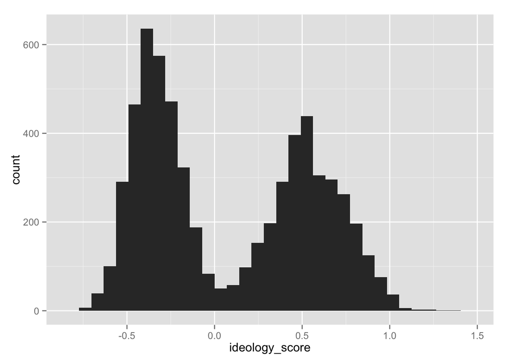

```r
qplot(ideology_score, data = nominate)
```

Many of the functions we use take a data argument. If they do not, though, we’ll need to use the `$` operator. Because we’ll almost always use data stored in data frames, you need to be sure to use one approach or the other. If the function has a data argument, use it. If not, use the `$` operator.

## How We’ll Always Use R

1. Start RStudio.
2. Set the working directory to whatever project you want to work on.
3. Open a new R script to do something new *OR* open a previously saved script to continue making progress.